# ‘Do frugivores spatially aggregate their feces and, if so, at what spatial scale?’

Maximilian H.K. Hesselbarth

02 August, 2019

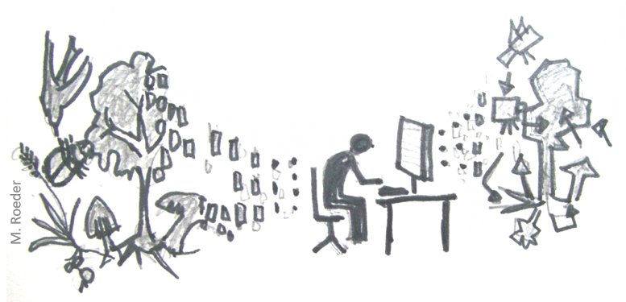

### Introduction

Please be aware and acknowledge that the data and analysis was published in: Fedriani, J.M., Wiegand, T., 2014. Hierarchical mechanisms of spatially contagious seed dispersal in complex seed-disperser networks. Ecology 95, 514–526.

For all further use of the data, a permission of the author must be obtained. We also ask you to not redistribute the data without asking for permission. For further questions about the data, please contact fedriani@csic.es!

### Set-up

First, we load the [`spatstat`](https://spatstat.org) library for spatial point pattern analysis (Baddeley and Turner, 2005). Also, we import the [`tidyverse`](https://www.tidyverse.org) library, a collection of `R` packages designed for data science (Wickham, 2017).

```r
# load packages
library(spatstat)
library(tidyverse)
```

If you don’t have the packages installed yet, run the following code in order to install them.

```r
# install packages if not installed yed
install.packages(c("spatstat", "tidyverse"))
```

Unfortunately, there is no nested cluster process (Wiegand et al., 2007) implemented in `spatstat`, yet. Therefore, we only fit a “simple” cluster process, namely the Thomas cluster process (Thomas, 1949).

### Import the data

To import the data, we use the `readr` package (Wickham et al., 2018), but you can use any other way you prefer to import the text file with the dataset as a `data.frame` (the columns are separated by a tab). By using `read_delim()`, the class of the imported data is automatically a `tibble`, an “advanced” version of a `data.frame`. For more information see `?tibble` from the `tibble` package (Müller and Wickham, 2019).

```r
# import point pattern data
feces_df <- read_delim(file = "Data/feces_dataset.txt",
                        delim = "\t")
```

The datasets contains the coordinates of all feces and the species of the frugivores. For the later analysis, we split the dataset into two datasets: one containing feces of all animals (so basically the original dataset) and one without feces of badgers. Therefore, we filter the original dataset for all cases in which the `mark != "badger"` and save the results into a new `tibble`.

```r
# only feces not belonging to badgers
feces_df_wb <- filter(feces_df,
                      mark != "badger")
```

Because we need to specify our study plot in which we want to conduct the spatial point pattern analysis, we need to import the corresponding coordinates as well.

```r
# import plot coordinates
plot_coords <- read_delim(file = "Data/plot_coords_a.txt",
                          delim = "\t")
```

Now, we need to convert the `tibble` to the `ppp` class of the `spatstat` packages. `ppp` objects are characterized by the coordinates of all points, possibly marks and a observation window (i.e. the study plot). Therefore, we use the previously imported coordinates to create an `owin` (observation window) object first. Afterwards, we create the final `ppp` object using the `tibble` with all coordinates and marks as well as the `owin` object.

```r
# create owin
obs_window <- owin(poly = list(x = plot_coords$x, y = plot_coords$y))

# create ppp with badgers
feces_ppp <- ppp(x = feces_df$x, y = feces_df$y,
                 marks = feces_df$mark,
                 window = obs_window)
```

It’s always a good idea to plot the data to get a general idea about it. We can see that it seems like feces tend to be spatially clustered. Therefore, we simulate this using a cluster process as null model.

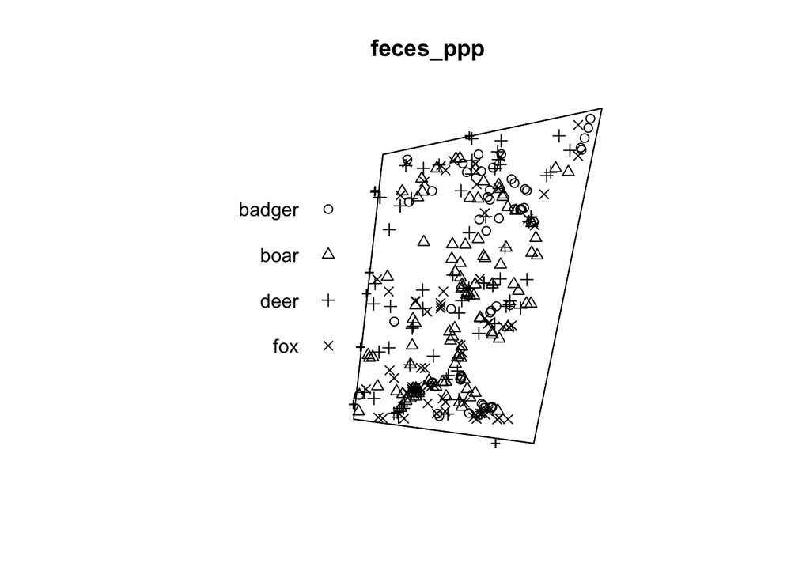

```r
# plot ppp
plot(feces_ppp)
```

### Fit and simulate the cluster process

To fit a “simple” cluster process, and more specifically a Thomas process, to the data, `spatstat` provides the `kppm()` function. We use the pair-correlation function (Stoyan and Stoyan, 1994) and the minimum contrast method to fit the cluster process.

```r
# fit cluster process
fitted_thomas <- kppm(X = unmark(feces_ppp),
                      statistic = "pcf",
                      statsargs = list(divisor = "d",
                                       correction = "Ripley"),
                      cluster = "Thomas", method = "mincon")
```

If we print the object, we get information about the model parameters (such as the intensity of cluster centers, the mean area of the clusters and the mean number of points within each cluster).

```r
# print object for model parameters
print(fitted_thomas)
## Stationary cluster point process model
## Fitted to point pattern dataset 'unmark(feces_ppp)'
## Fitted by minimum contrast
##  Summary statistic: pair correlation function
##
## Uniform intensity:   0.002622045
##
## Cluster model: Thomas process
## Fitted cluster parameters:
##        kappa        scale
## 0.0008109839 3.6596956018
## Mean cluster size:  3.233166 points
```

We now use the fitted cluster process to simulate random patterns as null model patterns. Because we want to use 199 simulations to construct the simulation envelopes later on, we set `nsim = 199`. The returning object is a list with simulated patterns using the Thomas cluster process with the previously fitted parameters.

```r
# set number of simulations
nsim <- 199

# simulate null model data
simulated_thomas <- simulate.kppm(object = fitted_thomas,
                                  nsim = nsim,
                                  window = obs_window)
## Generating 199 simulations... 1, 2, 3, 4.6.8.10.12.14.16.18.20.22.24.26.28.30.32.34.36.38.
## 40.42.44.46.48.50.52.54.56.58.60.62.64.66.68.70.72.74.76.78
## .80.82.84.86.88.90.92.94.96.98.100.102.104.106.108.110.112.114.116.
## 118.120.122.124.126.128.130.132.134.136.138.140.142.144.146.148.150.152.154.156
## .158.160.162.164.166.168.170.172.174.176.178.180.182.184.186.188.190.192.194.
## 196.198 199.
## Done.
```

### Construct simulation envelopes

To calculate the 5th highest and lowest values of the null model data, we use the `envelope()` function, which simply calculates the selected summary functions for all null model patterns provided and returns the specified highest and lowest values. `spatstat` provides the most commonly used summary functions, such as the pair-correlation function, the nearest-neighbor distribution function (Diggle, 2014) and the empty space function (Baddeley and Gill, 1994).

```r
# envelopes pair-correlation fun
envelope_pcf_thomas <- envelope(Y = unmark(feces_ppp),
                                fun = pcf,
                                nrank = 5,
                                simulate = simulated_thomas,
                                funargs = list(divisor = "d",
                                               correction = "Ripley"),
                                nsim = nsim)
# envelopes nearest-neighbor distribution fun
envelope_nnd_thomas <- envelope(Y = unmark(feces_ppp),
                                fun = Gest,
                                nrank = 5,
                                simulate = simulated_thomas,
                                funargs = list(correction = "km"),
                                nsim = nsim,
                                verbose = FALSE)

# envelopes empty-space function
envelope_epf_thomas <- envelope(Y = unmark(feces_ppp),
                                fun = Fest,
                                nrank = 5,
                                simulate = simulated_thomas,
                                funargs = list(correction = "km"),
                                nsim = nsim,
                                verbose = FALSE)
```

### Plot results

To have a look a the results, we simply plot the envelope object, e.g. the pair-correlation function. We can see, at shorter distances r, the null model underestimates to clustering of the observed pattern because the point densities of the simulated patterns at distance r are smaller compared to the observed point pattern. The clustering is also even stronger than the Thomas cluster process can simulate.

[figure not shown]

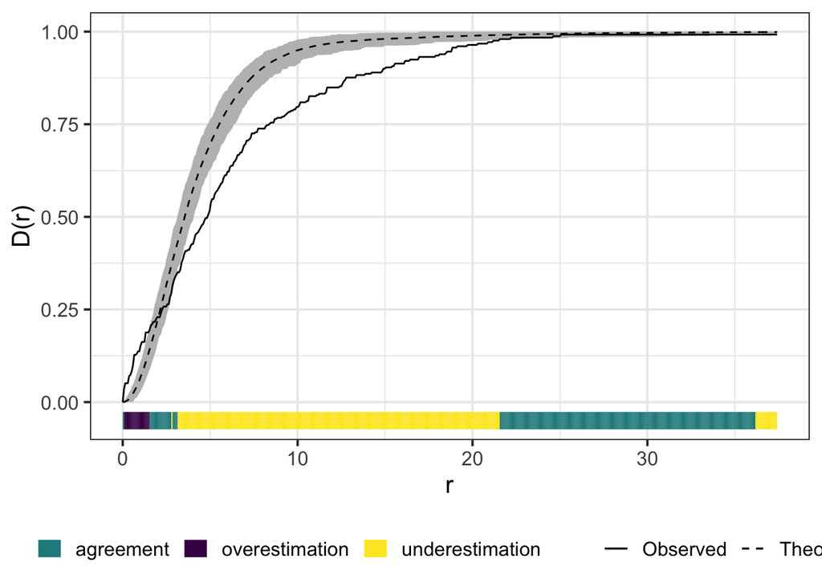

```r
# load library
library(onpoint)

# plot nndf with quantums
plot_quantums(envelope_nnd_thomas,
              ylab = "D(r)")
```

### Conclusion

The “simple” Thomas cluster process could not provide a satisfactory fit to the data. The clustering in the data was stronger than simulated by the null model.

As a next step, you could try to redo the analysis with dataset not including feces of badgers, as done in the original publication (Fedriani and Wiegand, 2014).

As already mentioned, currently we can’t fit a nested cluster process to the data using `spatstat`. However, Fedriani and Wiegand (2014) showed that this null model provides a much better fit to the data.

### References

Baddeley, A., Gill, R.D., 1994. The empty space hazard of a spatial pattern (No. 1994/3), Research Report. Department of Mathematics, University of Western Australia.

Baddeley, A., Turner, R., 2005. spatstat: An R package for analyzing spatial point patterns. J. Stat. Softw. 12, 1–42.

Diggle, P.J., 2014. Statistical analysis of spatial point patterns and spatio-temporal point patterns, 3. ed. Chapman and Hall/CRC Press, Boca Raton.

Fedriani, J.M., Wiegand, T., 2014. Hierarchical mechanisms of spatially contagious seed dispersal in complex seed-disperser networks. Ecology 95, 514–526.

Hesselbarth, M.H.K., 2019. onpoint: Helper functions for point pattern analysis. R package version 0.2.1.

Müller, K., Wickham, H., 2019. tibble: Simple Data Frames. R package version 2.1.3.

Stoyan, D., Stoyan, H., 1994. Fractals, random shapes and point fields. John Wiley & Sons, Chichester.

Thomas, M., 1949. A generalization of Poisson’s binomial limit for use in ecology. Biometrika 36, 18–25.

Wickham, H., 2017. tidyverse: Easily Install and Load the “Tidyverse”. R package version 1.2.1.

Wickham, H., Hester, J., Francois, R., 2018. readr: Read Rectangular Text Data. R package version 1.3.1.

Wiegand, T., Savitri Gunatilleke, C.V., Nimal Gunatilleke, I.A.U., Okuda, T., 2007. Analyzing the spatial structure of a Sri Lankan tree species with multiple scales of clustering. Ecology 88, 3088–3102.

[Maximilian H.K. Hesselbarth](https://mhesselbarth.rbind.io/)

*maximilian.hesselbarth@uni-goettingen.de*